# Pronóstico de ventas semanales

Proyecto Módulo 2 · Series de Tiempo · Equipo 1

Fernanda Dueñas

Santiago Villegas

Carlos Nieves

23 de octubre de 2026

# Datos

## Ventas semanales y esquema de evaluación

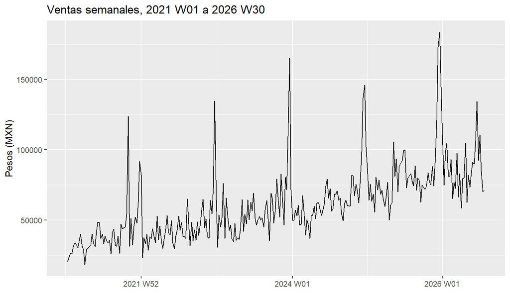

- 290 semanas sin huecos.
- Pronóstico: **2026 W31–W42**, 12 semanas.
- Entrenamiento hasta 2026 W18 y prueba en 2026 W19–W30.
- Revisión adicional en la misma temporada (W31–W42) de 2023, 2024 y 2025.
- Criterio de selección: **MAPE**, la métrica del concurso.

```r
h <- 12
ventas_train <- ventas_semana_train |>
  slice_head(n = nrow(ventas_semana_train) - h)
ventas_test <- ventas_semana_train |>
  slice_tail(n = h)
```

# Transformación y outliers

## Transformación: la escala original pronostica mejor

Mismo modelo (STL robusta + ETS) en tres escalas, evaluado en 2026 W19–W30:

| Escala | MAPE | RMSE (MXN) |
| --- | --- | --- |
| **Pesos, sin transformar** | **11.47 %** | 15410 |
| Box-Cox, $\lambda$ = 0.531 | 13.23 % | 14761 |
| Logaritmo | 13.69 % | 14598 |

- $\lambda$ de Guerrero estimada **solo con el entrenamiento**: 0.531 (con las 290 semanas sería 0.460).
- Box-Cox y logaritmo **aumentan el MAPE**; el logaritmo solo mejora el RMSE.
- Las ventas son positivas y el pronóstico se mantiene positivo sin transformar.

**Decisión:** modelar las ventas en pesos.

## Outliers: los identificamos, pero no los sustituimos

```r
c_threshold <- 3

ventas_dcmp <- ventas_train |>
  model(stl = STL(total ~ season(period = "year"), robust = TRUE)) |>
  components()

ventas_outliers <- ventas_dcmp |>
  filter(
    remainder < quantile(remainder, 0.25) - c_threshold * IQR(remainder) |
    remainder > quantile(remainder, 0.75) + c_threshold * IQR(remainder)
  )

ventas_outliers |>
  as_tibble() |>
  select(semana, total, remainder)
```

```
# A tibble: 6 × 3
    semana   total remainder
    <week>   <dbl>     <dbl>
1 2021 W43 123862.    71545.
2 2021 W50  62500.   -42885.
3 2021 W51  91835.   -43977.
4 2022 W50  72958.   -38850.
5 2025 W52 144517.    37786.
6 2026 W01 110387.    39363.
```

- Regla IQR ($c = 3$) sobre el residuo de una **STL anual robusta**, solo con el entrenamiento.
- Prueba: quitar esas semanas, `fill_gaps()` e imputar con `ARIMA() |> interpolate()`.

| Tratamiento | MAPE test |
| --- | --- |
| **Conservar los datos** | **11.47 %** |
| Imputar con ARIMA | 11.50 % |

**Decisión:** conservar las ventas originales.

# Modelado

## Modelos probados

```r
benchmark_spec <- decomposition_model(
  STL(total ~ season(period = "year"), robust = TRUE),
  RW(season_adjust ~ drift())
)
stl_ets_spec <- decomposition_model(
  STL(total ~ season(period = "year"), robust = TRUE),
  ETS(season_adjust ~ season("N"))
)
stl_arima_spec <- decomposition_model(
  STL(total ~ season(period = "year"), robust = TRUE),
  ARIMA(season_adjust ~ PDQ(0, 0, 0), approximation = FALSE)
)

ventas_fit <- ventas_train |>
  model(
    benchmark = benchmark_spec,
    stl_ets   = stl_ets_spec,
    stl_arima = stl_arima_spec,
    sarima    = ARIMA(total, approximation = FALSE)
  )
```

```
Warning: Non-integer lag orders for random walk models are not supported. Rounding to
the nearest integer.
Non-integer lag orders for random walk models are not supported. Rounding to
the nearest integer.
Non-integer lag orders for random walk models are not supported. Rounding to
the nearest integer.
```

| Modelo | Lo que estimó R |
| --- | --- |
| `benchmark` | STL + RW con deriva + SNAIVE |
| `stl_ets` | STL + **ETS(A,N,N)** + SNAIVE |
| `stl_arima` | STL + ARIMA(1,1,2) con deriva + SNAIVE |
| `sarima` | ARIMA(0,1,1)(0,1,1)[52] |
| `stl_ets_log`, `stl_ets_bc` | STL + ETS(A,A,N) + SNAIVE |
| `stl_ets_limpio` | STL + ETS(A,N,N) sobre datos imputados |

Estructuras confirmadas con `report()` (siguiente diapositiva). El aviso de R indica que el periodo anual, 52.18 semanas, se redondea a 52 en SNAIVE.

## Verificación con `report()`: lo especificado es lo estimado

```r
ventas_fit |>
  select(stl_ets) |>
  report()
```

```
Series: total
Model: STL decomposition model
Combination: ETS(A,N,N) + SNAIVE

================================

Series: season_adjust
Model: ETS(A,N,N)
  Smoothing parameters:
    alpha = 0.1441126

  Initial states:
     l[0]
 37247.28

  sigma^2:  129626079

     AIC     AICc      BIC
6761.557 6761.645 6772.440

Series: season_year
Model: SNAIVE

sigma^2: 138277.1511
```

```r
ventas_fit |>
  select(stl_arima) |>
  report()
```

```
Series: total
Model: STL decomposition model
Combination: ARIMA(1,1,2) w/ drift + SNAIVE

===========================================

Series: season_adjust
Model: ARIMA(1,1,2) w/ drift

Coefficients:
         ar1      ma1     ma2  constant
      0.7425  -1.5931  0.6020   52.5236
s.e.  0.1273   0.1376  0.1317    7.0110

sigma^2 estimated as 123814482:  log likelihood=-2973.08
AIC=5956.17   AICc=5956.39   BIC=5974.29

Series: season_year
Model: SNAIVE

sigma^2: 138277.1511
```

```r
ventas_fit |>
  select(sarima) |>
  report()
```

```
Series: total
Model: ARIMA(0,1,1)(0,1,1)[52]

Coefficients:
          ma1     sma1
      -0.9499  -0.2835
s.e.   0.0252   0.0867

sigma^2 estimated as 174281659:  log likelihood=-2456.44
AIC=4918.88   AICc=4918.98   BIC=4929.12
```

## Modelo final: STL robusta + ETS(A,N,N) + SNAIVE

```r
ventas_final_fit <- ventas_semana_train |>
  model(stl_ets = stl_ets_spec)
ventas_final_fit |>
  report()
```

```
Series: total
Model: STL decomposition model
Combination: ETS(A,N,N) + SNAIVE

================================

Series: season_adjust
Model: ETS(A,N,N)
  Smoothing parameters:
    alpha = 0.1379085

  Initial states:
     l[0]
 37238.57

  sigma^2:  130811269

     AIC     AICc      BIC
7068.146 7068.230 7079.155

Series: season_year
Model: SNAIVE

sigma^2: 194552.2447
```

$$y_t = \underbrace{S_t}_{\text{SNAIVE}} + \underbrace{A_t}_{\text{ETS(A,N,N)}}$$

- **STL robusta anual**: separa `season_year` y reduce el peso de las semanas extremas.
- **ETS(A,N,N)** sobre `season_adjust`: el nivel se actualiza con $\alpha \approx 0.14$ y se proyecta sin tendencia.
- **SNAIVE** repite el último patrón estacional estimado.
- Respecto al benchmark solo cambia una pieza: **ETS en lugar de la deriva**.

# Evaluación

## Prueba 2026 W19–W30: comparación con el benchmark

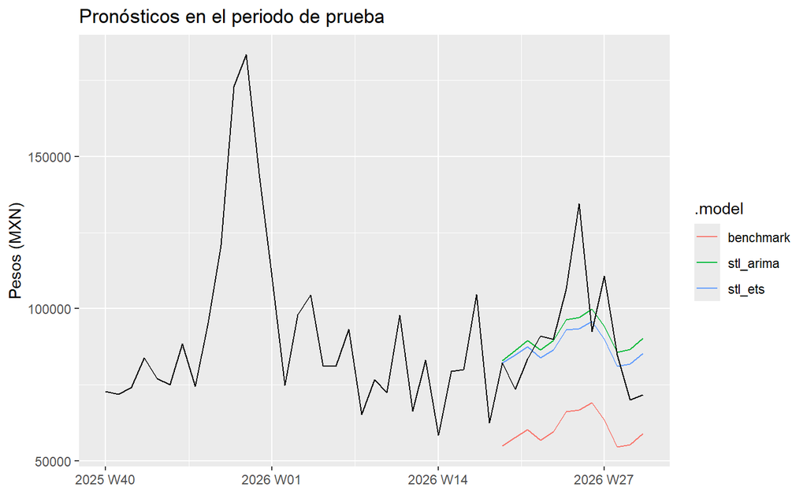

```
# A tibble: 7 × 4
  .model         MAPE  RMSE  MASE
  <chr>          <chr> <chr> <chr>
1 stl_ets        11.47 15410 0.79
2 stl_ets_limpio 11.50 15416 0.80
3 stl_arima      11.84 14902 0.78
4 stl_ets_bc     13.23 14761 0.84
5 stl_ets_log    13.69 14598 0.86
6 sarima         17.66 18070 1.07
7 benchmark      32.05 34076 2.18
```

`stl_ets` tiene el menor MAPE y reduce el error del benchmark a casi la tercera parte.

## La misma temporada en años anteriores (W31–W42)

[output not shown]

MAPE entrenando hasta W30 de cada año y pronosticando W31–W42:

| Temporada | STL + ETS | STL + ARIMA | Benchmark |
| --- | --- | --- | --- |
| 2023 | 16.12 | 16.57 | **15.71** |
| 2024 | 12.04 | **11.84** | 15.91 |
| 2025 | **14.27** | 14.88 | 15.26 |
| **Promedio** | **14.15** | 14.43 | 15.63 |

Crecimiento frente a las mismas semanas de 2025:

|  | Crecimiento |
| --- | --- |
| Observado 2026 W01–W30 | 13.1 % |
| Observado 2026 W19–W30 | 3.4 % |
| Pronóstico STL + ETS | 13.8 % |
| Pronóstico STL + ARIMA | 18.1 % |

**Elegimos STL + ETS:** menor MAPE promedio en la temporada objetivo, más simple y con un nivel acorde al crecimiento observado, que se está frenando.

## Diagnóstico de residuales del modelo final

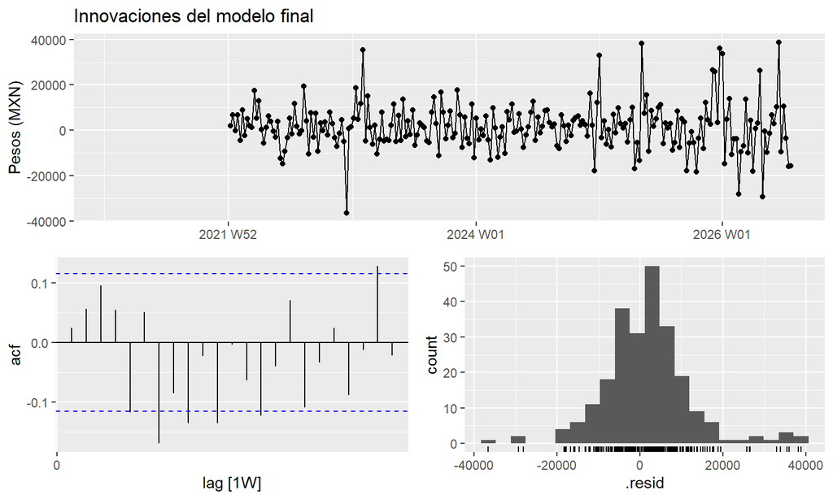

- Ljung-Box, 24 rezagos: $p$ = 0.0098.
- **Queda autocorrelación**: los residuales no son ruido blanco.
- Media positiva, cerca de 1586 pesos: ligera subestimación dentro de muestra.
- Mayor dispersión en 2025–2026.
- Las primeras 52 semanas no tienen innovación porque SNAIVE necesita un año previo.

Limitaciones: Semana Santa cambia de semana cada año, el calendario ISO tiene años de 53 semanas y no conocemos eventos ni cierres.

# Pronóstico final

## Pronóstico entregado: 2026 W31–W42

```r
equipo_1 <- ventas_semana_train |>
  model(
    equipo_1 = decomposition_model(
      STL(total ~ season(period = "year"),
          robust = TRUE),
      ETS(season_adjust ~ season("N"))
    )
  ) |>
  forecast(h = 12)
```

Media semanal pronosticada: **86267 pesos**, 13.8 % más que W31–W42 de 2025.

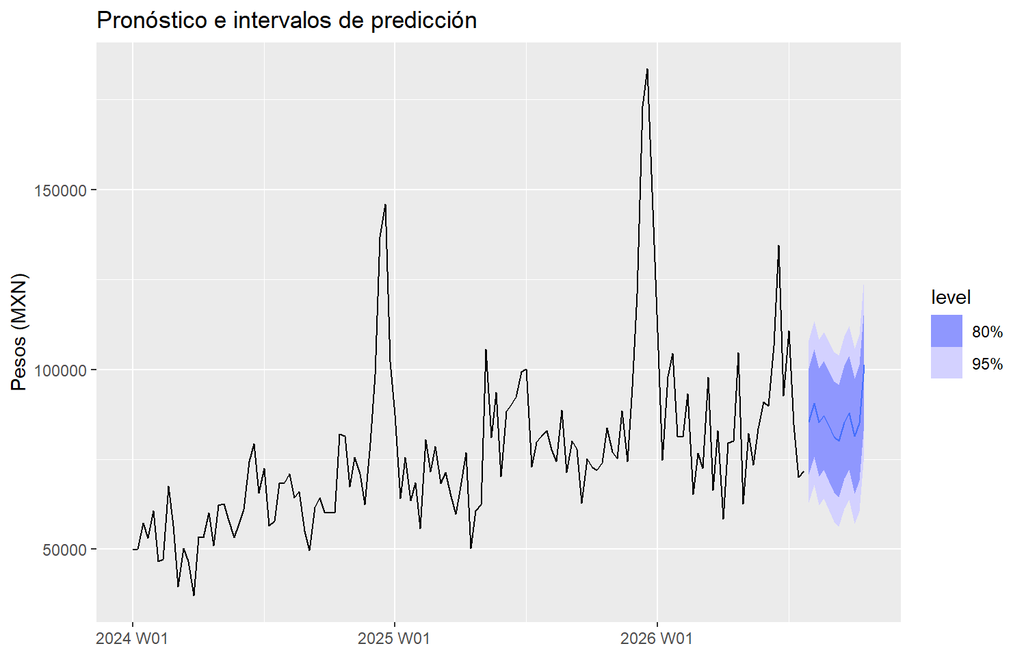

## Validación y guardado de la entrega

```r
validar_entrega <- function(fc, nombre, maestria = FALSE,
                            inicio = yearweek("2026 W31")) {
  semanas_esperadas <- inicio + 0:11
  problemas <- character()
  if (!inherits(fc, "fbl_ts")) {
    stop("El objeto no es un fable (fbl_ts). Debe ser la salida de forecast().")
  }
  idx <- fc[[index_var(fc)]]
  if (!inherits(idx, "yearweek")) {
    problemas <- c(problemas, "El índice no es de clase yearweek.")
  }
  modelos <- unique(fc$.model)
  if (length(modelos) != 1 || modelos[1] != nombre) {
    problemas <- c(problemas, sprintf(
      "Debe haber un solo modelo llamado '%s'. Se encontró: %s",
      nombre, paste(modelos, collapse = ", ")
    ))
  }
  if (nrow(fc) != 12 ||
      !isTRUE(all.equal(sort(as.Date(idx)), as.Date(semanas_esperadas)))) {
    problemas <- c(problemas,
      paste("El pronóstico debe cubrir exactamente 12 semanas, de",
            format(inicio), "a", format(inicio + 11)))
  }
  if (!identical(response_vars(fc), "total")) {
    problemas <- c(problemas, "La variable pronosticada debe llamarse 'total'.")
  }
  if (anyNA(fc$.mean) || any(fc$.mean <= 0)) {
    problemas <- c(problemas, "Hay pronósticos faltantes, negativos o en cero.")
  }
  if (maestria) {
    v <- distributional::variance(fc[[distribution_var(fc)]])
    if (anyNA(v) || any(v <= 0)) {
      problemas <- c(problemas,
        "La distribución del pronóstico es degenerada: no hay intervalos válidos.")
    }
  }
  if (length(problemas) == 0) {
    message("✔ Entrega válida.")
  } else {
    stop(paste0("✖ ", problemas, collapse = "\n"))
  }
  invisible(TRUE)
}
```

```
# A tibble: 6 × 2
    semana .mean
    <week> <chr>
1 2026 W31 85485.25
2 2026 W32 90658.56
3 2026 W33 85253.73
4 2026 W34 87237.70
5 2026 W35 84058.96
6 2026 W36 81311.54
```

```
# A tibble: 6 × 2
    semana .mean
    <week> <chr>
1 2026 W37 80140.07
2 2026 W38 85296.39
3 2026 W39 87914.37
4 2026 W40 81449.02
5 2026 W41 85112.32
6 2026 W42 101283.70
```

```r
validar_entrega(equipo_1, "equipo_1")
```

```
✔ Entrega válida.
```

```r
save(equipo_1, file = "equipo_1.RData")
```